# HASHING

Pencarian akan lebih cepat lagi jika semua data pada list terletak tepat berada ditempatnya masing-masing, sehingga pencarian dilakukan hanya dengan satu kali proses perbandingan saja. Algoritma ini dikenal dengan nama Hashing. Di dalam algoritma hashing ini terdapat beberapa istilah dasar sebagai berikut:

- Hash Table, yaitu sebuah tempat penyimpanan data, yang dibuat sedemikian rupa, sehingga dapat memudahkan pencarian. Tipe data list di python dapat digunakan untuk merepresentasikan hash table
- slot, yaitu posisi (indeks) yang terdapat pada hash table sebagai tempat penyimpanan setiap data. Karena slot berfungsi seperti halnya indeks, maka nilai slot adalah nilai integer mulai dari nol sampai dengan ukurang dari hash table, misalkan slot 0, slot 1, slot 2, .... , slot . Contoh hash table dan slot yang masih kosong dapat dilihat pada Gambar 1. Pada Gambar tersebut terdapat sebuah hash table dengan 11 slot kosong :

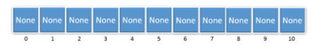

- Hash function, yaitu suatu fungsi yang memetakan antara data dengan slot di dalam hash table

## FUNGSI HASH

Hash function ini memegang peranan penting dalam algoritma hashing, dengan hash function ini, data didalam list disusun berdasarkan nilai hash, dan pencarian data dilakukan berdasarkan nilai hash dari hash function ini. Hash function memiliki parameter nilai data (baik data yang akan disusun didalam list ataukah data yang akan dicari), dan mengembalikan nilai integer (nilai hash) yang merupakan representasi dari nomor slot.

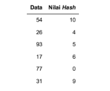

Sehingga dengan data dan nilai hash tersebut, maka representasi data di dalam hash table, dapat dilihat pada Gambar 2 berikut.

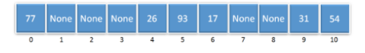

Pencarian data dilakukan hanya dengan cara menghitung function hash berdasarkan data tersebut, dan nilai balik data tersebut merupakan index atau slot dari data di dalam list, kemudian dilakukan pengecekan keberadaan data tersebut hanya dengan satu kali perbandingan saja.

```python
class hash:
  def __init__(self):
    self.panjang=10
    self.table=self.hashtable()

  def hashfunction(self, data):
    return data% self.panjang

  def hashtable(self):
    return [None for i in range(self.panjang)]

  def appendtable(self,data):
    for i in range(len(data)):
      idx= self.hashfunction(data[i])
      if self.table[idx]==None:
        self.table[idx]=[data[i]]
      else:
        self.table[idx].append(data[i])

  def searchhash(self,target):
    idx=self.hashfunction(target)
    if self.table[idx]!=None:
      for el in self.table[idx]:
        if el==target:
          return True
    return False

varhash=hash()
data=[1,2,3,4,5,6,7,10,20]
varhash.appendtable(data)
print(varhash.searchhash(10))
print(varhash.searchhash(20))
print(varhash.table)
```

```
True
True
[[10, 20], [1], [2], [3], [4], [5], [6], [7], None, None]
```

## Penanganan Collusion

Perfect Hash Function meminimalisir terjadinya colluision, akan tetapi terkadang, collusion ini tidak dapat dihindari, sehingga diperluka penanganan atau yang dikenal dengan collusion resolution. Penangan collusion ini dapat dilakukan dengan cara mencari kembali di dalam hash table slot yang kosong untuk data yang menyebabkan terjadinya collusion. Penanganan ini dikenal dengan konsep open addressing, yaitu pencarian slot kosong yang siap ditempati oleh data baru. Contoh penanganan collusion sederhana berdasarkan konsep open adressing ini adalah Linear Probing, yaitu mencari slot kosong dengan cara mengunjungi slot-slot ini satu persatu, dimulai dari slot tempat terjadinya collusion.

```python
def createHashTable(panjang):
    return ['none'] * panjang


def remainderFunction(data, panjang):
    return data % panjang


def linearProbing(ind, hashTable, data):
    count = ind
    found = False

    while (count != ind - 1) and not found:

        if hashTable[count] == 'none':
            found = True
            hashTable[count] = data

        else:
            count = count + 1

            if count == len(hashTable):
                count = 0

    return hashTable


def putData3(a, hashTable, functionName):

    for i in range(len(a)):

        if functionName == 'reminder':
            ind = remainderFunction(a[i], len(hashTable))

        if hashTable[ind] == 'none':
            hashTable[ind] = a[i]

        else:
            hashTable = linearProbing(ind, hashTable, a[i])

    return hashTable


a = [54, 26, 93, 17, 77, 31]

hashTable = createHashTable(11)

print(hashTable)

hashTable = putData3(a, hashTable, 'reminder')

print(hashTable)
```

```
['none', 'none', 'none', 'none', 'none', 'none', 'none', 'none', 'none', 'none', 'none']
[77, 'none', 'none', 'none', 26, 93, 17, 'none', 'none', 31, 54]
```

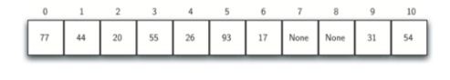

Metode lain untuk penanganan collusion ini adalah Chaining, dengan chaining ini, satu slot dapat ditempati oleh beberapa data sekaligus. Untuk proses pencarian dilakukan pada slot tersebut. Contoh chaining ini dapat dilihat pada Gambar berikut

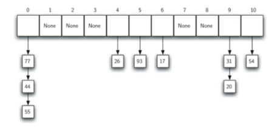